# Reproducible Data Analysis Project

weixuan xiao

2022-05-08

# 1.Introduction

This section provide some relevant background information and justification for the project.

1.The American Professional Basketball League is a men’s professional basketball league composed of 30 professional teams.

There are five different positions defined in the rules of basketball.

2.Chicago Bull place 27th out of 30 in 2018-19 season, and own 112,598,201$ budgets in the 2019-2020 season

3.The aim of this project is firstly anaalysis what key metrics cause higher team rank, secondary find out what key metrics determine better players,thirdly is find the best five starting players through the previous analysis.

4. Create a multiple linear regression model measure relationship between and different key metrics with total wins, other multiple regression model measure the relationship between different key metrics, justify the model then select best five starting players.

##2.load all the required library

```r
library(tidyverse)
library(broom)
library(ggplot2)
library(car)
```

###Reading raw data #

```r
team_playroll <- read_csv("2019-20_nba_team-payroll.csv")

team_statistics1 <- read_csv("2018-19_nba_team-statistics_1.csv")
team_statistics1

team_statistics2 <- read_csv("2018-19_nba_team-statistics_2.csv")


player_salaries <- read_csv("2018-19_nba_player-salaries.csv")
player_salaries

player_statistic <- read_csv("2018-19_nba_player-statistics.csv")

str(team_playroll) #provides structure
head(team_playroll) #shows first 6 rows
tail(team_playroll) #shows last 6 rows

str(player_salaries) #provides structure
head(player_salaries) #shows first 6 rows
tail(player_salaries) #shows last 6 rows

str(player_statistic) #provides structure
head(player_statistic) #shows first 6 rows
tail(player_statistic) #shows last 6 rows

str(team_statistics1) #provides structure
head(team_statistics1) #shows first 6 rows
tail(team_statistics1) #shows last 6 rows

str(team_statistics2) #provides structure
head(team_statistics2) #shows first 6 rows
tail(team_statistics2) #shows last 6 rows
```

###Cleaning raw data

```r
team_statistics_sum <- left_join(team_statistics1,team_statistics2,by = "Team")

colSums(is.na(team_statistics_sum))


team_statistics_sum <- team_statistics_sum %>%
                        select(-"...23",-"...24",-"...25", -"Rk.y")

team_statistics_sum <- team_statistics_sum %>%
 rename( "FG_PERCENTAGE" = "FG%", "THREE_P" = "3P", "THREE_P_ATTEMPTS" = "3PA","THREE_POINT_PERCENTAGE" = "3P%",
        "TWO_P" = "2P", "TWO_P_ATTEMPTS" = "2PA","TWO_POINT_PERCENTAGE" = "2P%",
        "FREE_THROW_PERCENTAGE" = "FT%", "THREE_POINT_ATTEMPT_RATE" = "3PAr", "TRUE_SHOOTING_PRCENTAGE" = "TS%",
        "Effective_Field_Goal_Percentage" = "eFG%", "Turnover_Percentage" = "TOV%",
        "Offensive_Rebound_Percentage" = "ORB%", "Defensive_Rebound_Percentage" = "DRB%")
```

##Exploratory analysis

*Create visualizations to determine how each individual explanatory variable relates to the response variable.*

**Individual Offensive and Defensive Ratings, ORtg, DRtg functions are efficiency metricsdeveloped by Dean Oliver in his 2004 book Basketball on Paper.**

*ORtg: Offensive Rating; An estimate of points produced (players) or scored (teams) per 100 possessions

*DRtg : Defensive Rating; An estimate of points allowed per 100 possessions

*NRtg: Net Rating; an estimate of point differential per 100 possessions

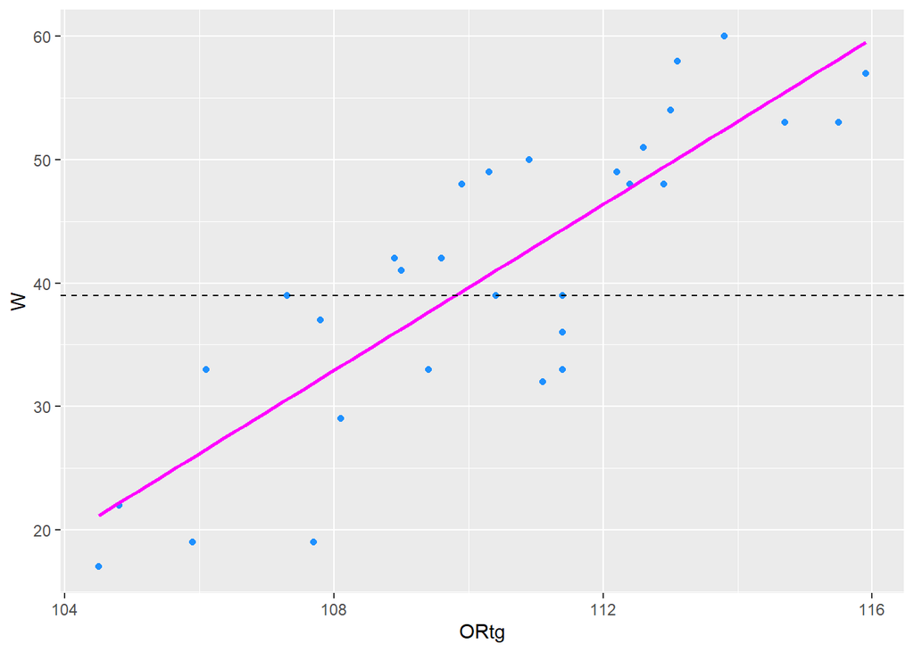

```r
ggplot(data = team_statistics_sum, aes(x = ORtg, y = W ))+
  geom_point(colour = "dodgerblue") +
  geom_smooth(method = "lm", colour = "magenta", se = FALSE) +
  geom_hline(yintercept = 39, colour = "black", linetype = "dashed")
```

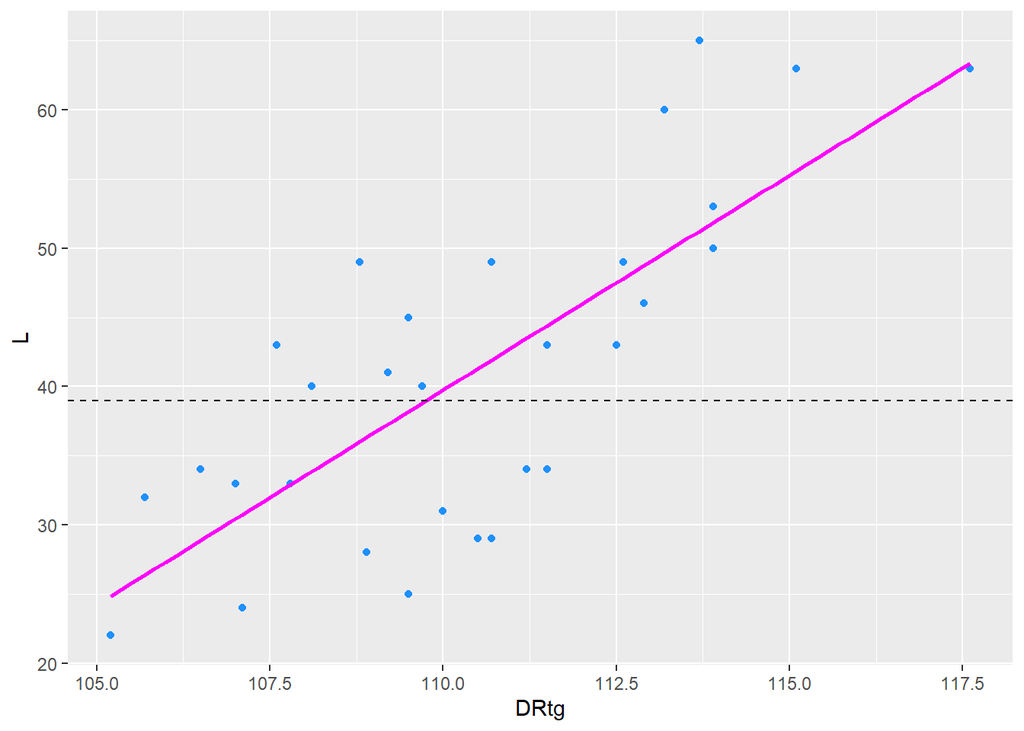

```r
ggplot(data = team_statistics_sum, aes(x = DRtg, y = L ))+
  geom_point(colour = "dodgerblue") +
  geom_smooth(method = "lm", colour = "magenta", se = FALSE) +
  geom_hline(yintercept = 39, colour = "black", linetype = "dashed")
```

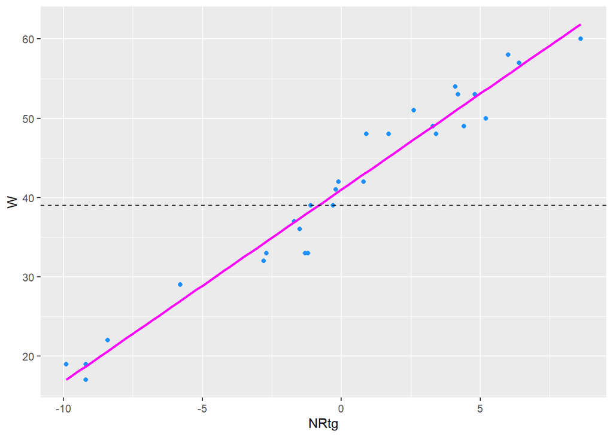

```r
ggplot(data = team_statistics_sum, aes(x = NRtg, y = W ))+
  geom_point(colour = "dodgerblue") +
  geom_smooth(method = "lm", colour = "magenta", se = FALSE) +
  geom_hline(yintercept = 39, colour = "black", linetype = "dashed")
```

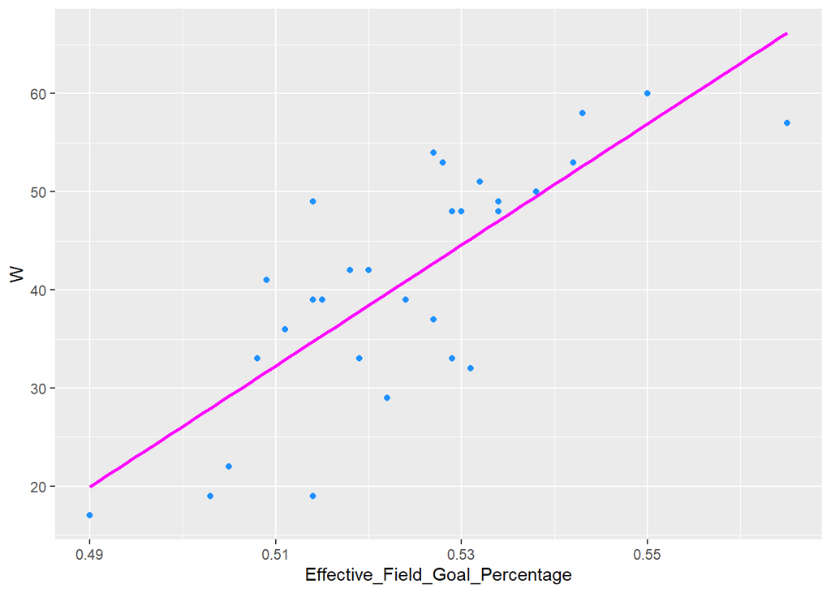

```r
ggplot(data = team_statistics_sum, aes(x = Effective_Field_Goal_Percentage, y = W ))+
  geom_point(colour = "dodgerblue") +
  geom_smooth(method = "lm", colour = "magenta", se = FALSE)
```

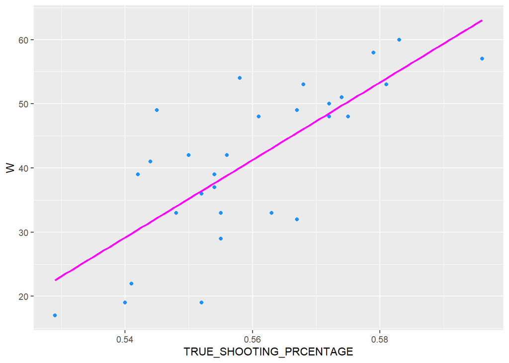

```r
ggplot(data = team_statistics_sum, aes(x = TRUE_SHOOTING_PRCENTAGE, y = W ))+
  geom_point(colour = "dodgerblue") +
  geom_smooth(method = "lm", colour = "magenta", se = FALSE)
```

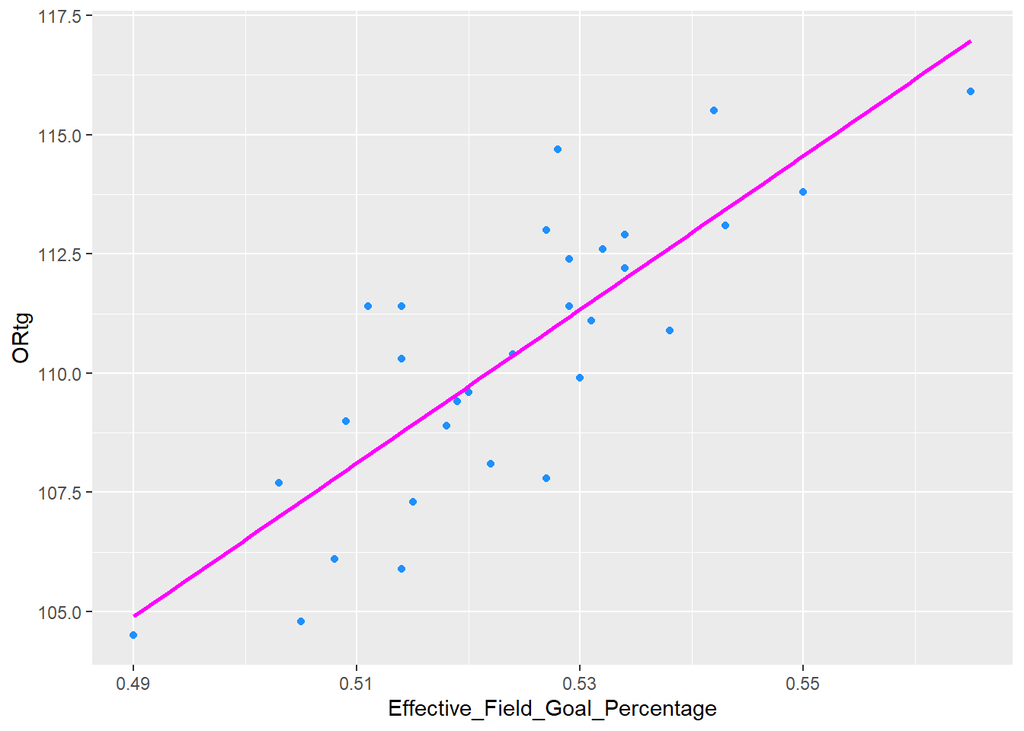

```r
ggplot(data = team_statistics_sum, aes(x = Effective_Field_Goal_Percentage, y = ORtg ))+
  geom_point(colour = "dodgerblue") +
  geom_smooth(method = "lm", colour = "magenta", se = FALSE)
```

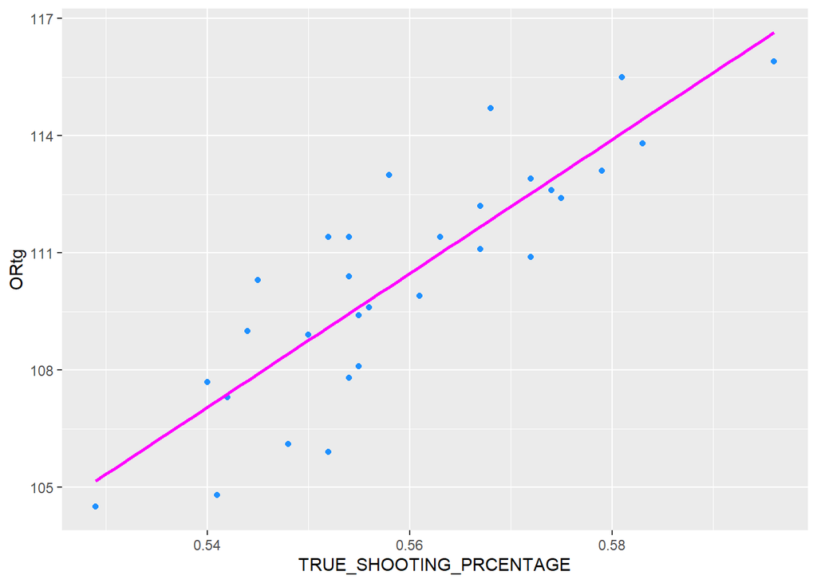

```r
ggplot(data = team_statistics_sum, aes(x = TRUE_SHOOTING_PRCENTAGE, y = ORtg ))+
  geom_point(colour = "dodgerblue") +
  geom_smooth(method = "lm", colour = "magenta", se = FALSE)
```

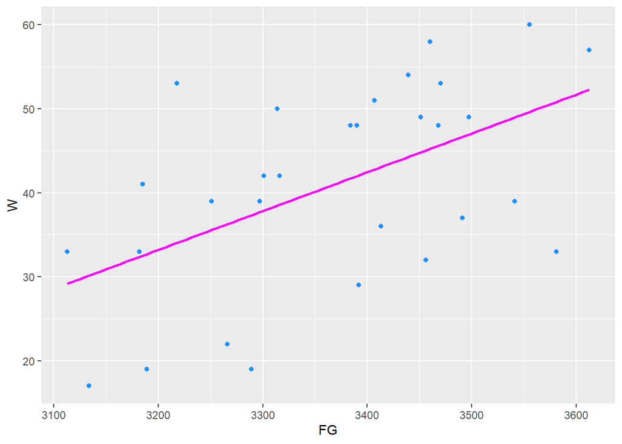

```r
ggplot(data = team_statistics_sum, aes(x = FG, y = W ))+
  geom_point(colour = "dodgerblue") +
  geom_smooth(method = "lm", colour = "magenta", se = FALSE)
```

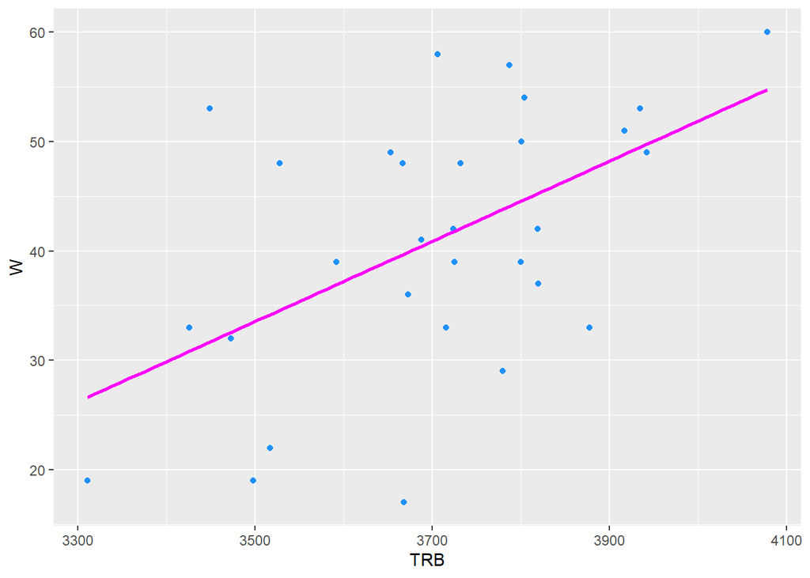

```r
ggplot(data = team_statistics_sum, aes(x = TRB, y = W ))+
  geom_point(colour = "dodgerblue") +
  geom_smooth(method = "lm", colour = "magenta", se = FALSE)
```

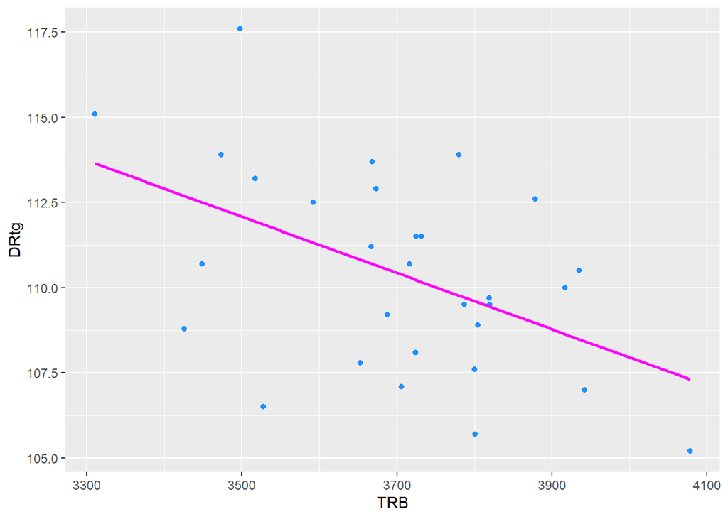

```r
ggplot(data = team_statistics_sum, aes(x = TRB, y = DRtg))+
  geom_point(colour = "dodgerblue") +
  geom_smooth(method = "lm", colour = "magenta", se = FALSE)
```

##Create a multiple linear regression model determine whether key metrics influence Total wins.

```r
fit <- lm(W ~ ORtg + DRtg , data = team_statistics_sum)
tidy(fit,conf.int = TRUE)
```

```
## # A tibble: 3 x 7
##   term        estimate std.error statistic  p.value conf.low conf.high
##   <chr>          <dbl>     <dbl>     <dbl>    <dbl>    <dbl>     <dbl>
## 1 (Intercept)    -7.77    28.1      -0.276 7.84e- 1   -65.4      49.9
## 2 ORtg            2.64     0.154    17.1   4.86e-16     2.33      2.96
## 3 DRtg           -2.20     0.157   -14.0   7.15e-14    -2.52     -1.88
```

```r
summary(fit)
```

```
##
## Call:
## lm(formula = W ~ ORtg + DRtg, data = team_statistics_sum)
##
## Residuals:
##     Min      1Q  Median      3Q     Max
## -5.8096 -1.0779  0.1196  1.4373  4.1294
##
## Coefficients:
##             Estimate Std. Error t value Pr(>|t|)
## (Intercept)  -7.7664    28.1126  -0.276    0.784
## ORtg          2.6414     0.1541  17.145 4.86e-16 ***
## DRtg         -2.1996     0.1575 -13.967 7.15e-14 ***
## ---
## Signif. codes:  0 '***' 0.001 '**' 0.01 '*' 0.05 '.' 0.1 ' ' 1
##
## Residual standard error: 2.351 on 27 degrees of freedom
## Multiple R-squared:  0.9644, Adjusted R-squared:  0.9618
## F-statistic: 366.1 on 2 and 27 DF,  p-value: < 2.2e-16
```

**intercept coefficient = -7.77, meaning that when ORtg and DRtg is 0, expected Total wins is -7.77.** **this does not make much practical sense as ORtg and DRtg will never be 0 and Total wins can not be a negative, it is juct a starting for the model.**

**slope coefficient = 2.64, meaning that for every 1 unit that ORtg is incresaed, the expected Total wins increases by 2.64.**

**slope coefficient = -2.20, meaning that for every 1 unit that DRtg is incresaed, the expected Total wins increases by -2.20.**

**Multiple R-squared = 0.9644, meaning that 96.44% of the variance in Total wins is explained by the variance in ORtg and DRtg.**

##Independce for model 1

**There should be a linear relationship between the response variable (W) and each explanatory variable.**

```r
#Determine if our linear regression meets the assumption of independence of observations.
car::durbinWatsonTest(fit)
```

```
##  lag Autocorrelation D-W Statistic p-value
##    1       0.1360223       1.70813   0.306
##  Alternative hypothesis: rho != 0
```

**The results are 1.70813, which is close to the recommended 2 to ensure independence. thus we have not failed this assumption.**

## 5. Outliers, Influential and High Leverage Points for model1

**Outliers influential high leveage point leverage cause unreliable model identify any and potentially remove them from the model**

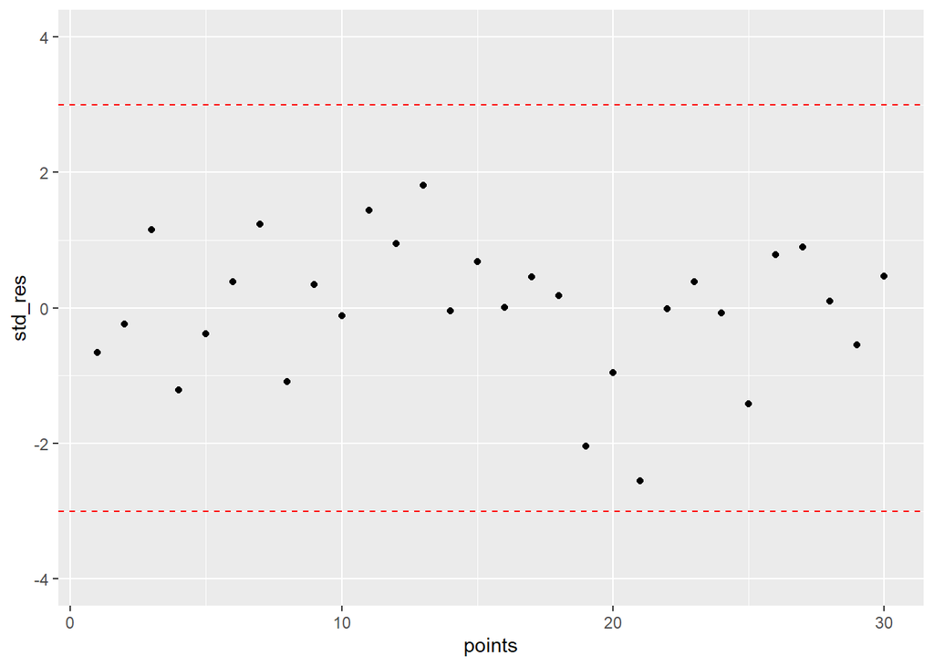

```r
std_res <- rstandard(fit)
points <- 1:length(std_res)
ggplot(data = NULL, aes(x = points, y = std_res)) +
  geom_point() +
  ylim(c(-4,4)) +
  geom_hline(yintercept = c(-3, 3), colour = "red", linetype = "dashed")
```

**Determine if there are any high leverage points that have the potential to influence the model.**

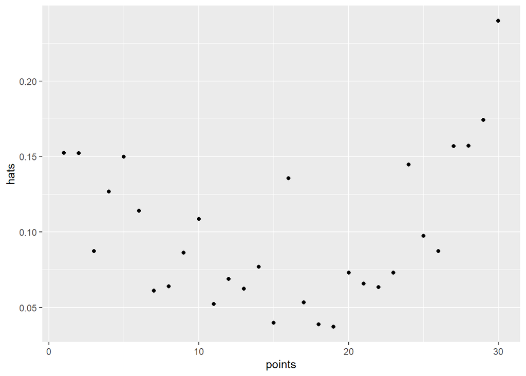

```r
#Check to see if any of the potential outliers create leverage, using hatvalues.
hats <- hatvalues(fit)

ggplot(data = NULL, aes(x = points, y = hats)) +
  geom_point()
```

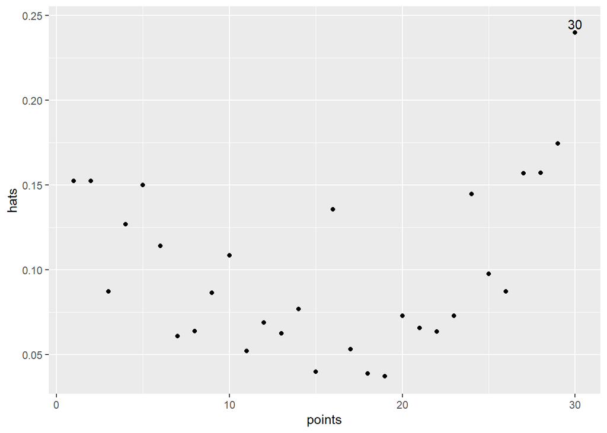

```r
hat_labels <- if_else(hats >= 0.20, paste(points), "")

ggplot(data = NULL, aes(x = points, y = hats)) +
  geom_point() +
  geom_text(aes(label = hat_labels), nudge_y = 0.005)
```

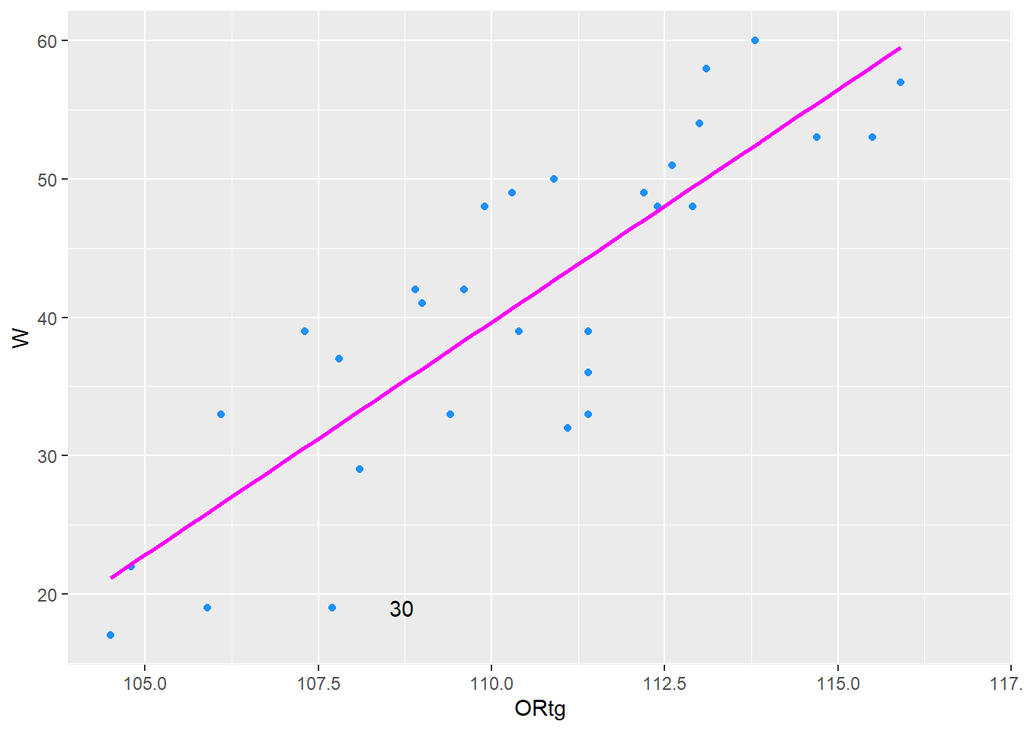

```r
ggplot(data = team_statistics_sum, aes(x = ORtg, y = W)) +
  geom_point(colour = "dodgerblue") +
  geom_smooth(method = "lm", colour = "magenta", se = FALSE) +
  geom_text(aes(label = hat_labels), nudge_x = 1)
```

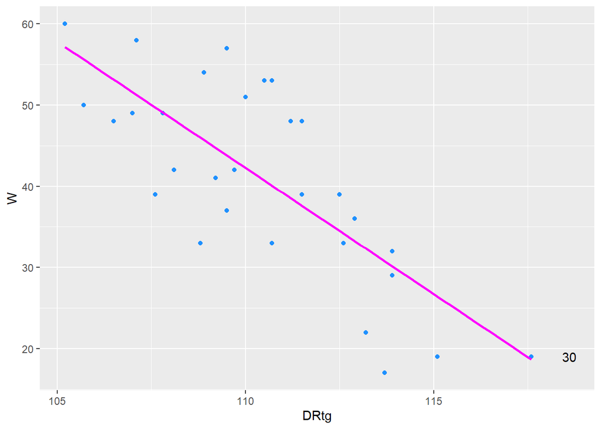

```r
ggplot(data = team_statistics_sum, aes(x = DRtg, y = W)) +
  geom_point(colour = "dodgerblue") +
  geom_smooth(method = "lm", colour = "magenta", se = FALSE) +
  geom_text(aes(label = hat_labels), nudge_x = 1)
```

**There do not appear to be any leverage points as all hatvalues are closer to 0 than 1, although there are a points (30) in particular that are above 0.2 that we should look at potentially investigating.**

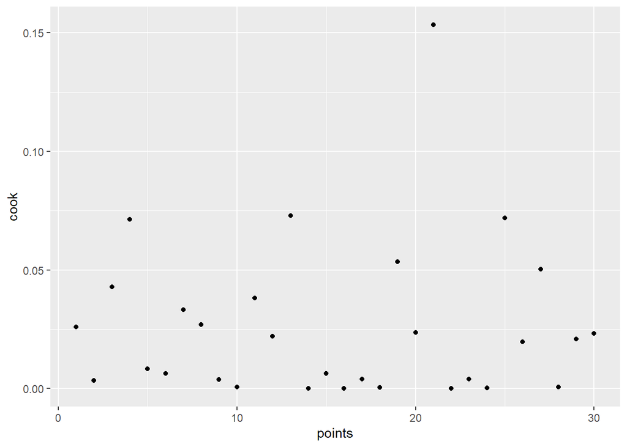

```r
#Check for influence on the linear regression by potential outliers.

cook <- cooks.distance(fit)


ggplot(data = NULL, aes(x = points, y = cook)) +
  geom_point()
```

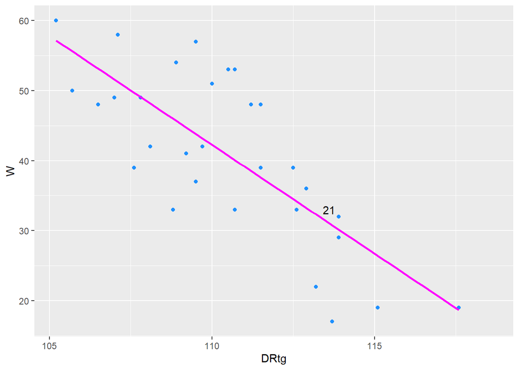

```r
cook_labels <- if_else(cook >= 0.15, paste(points), "")


ggplot(data = team_statistics_sum, aes(x = DRtg, y = W)) +
  geom_point(colour = "dodgerblue") +
  geom_smooth(method = "lm", colour = "magenta", se = FALSE) +
  geom_text(aes(label = cook_labels), nudge_x = 1)
```

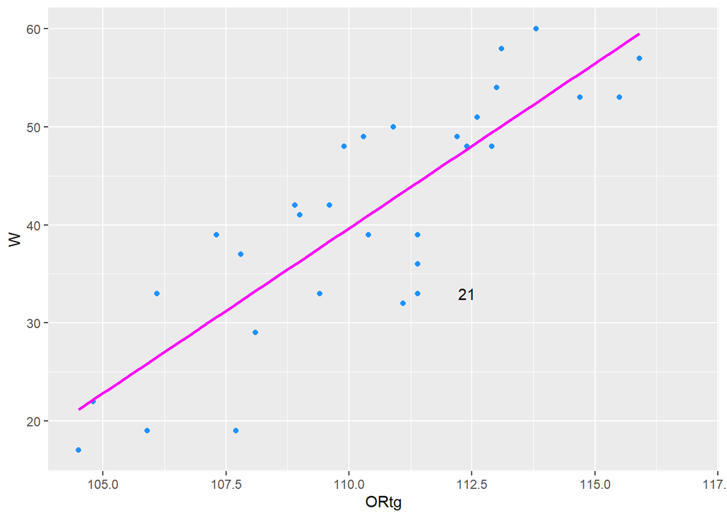

```r
ggplot(data = team_statistics_sum, aes(x = ORtg, y = W)) +
  geom_point(colour = "dodgerblue") +
  geom_smooth(method = "lm", colour = "magenta", se = FALSE) +
  geom_text(aes(label = cook_labels), nudge_x = 1)
```

**It does not appear that points 30 are showing any influence or leverage in this instance, but this TIME the POINT 21 has shown up in our checks for validity.**

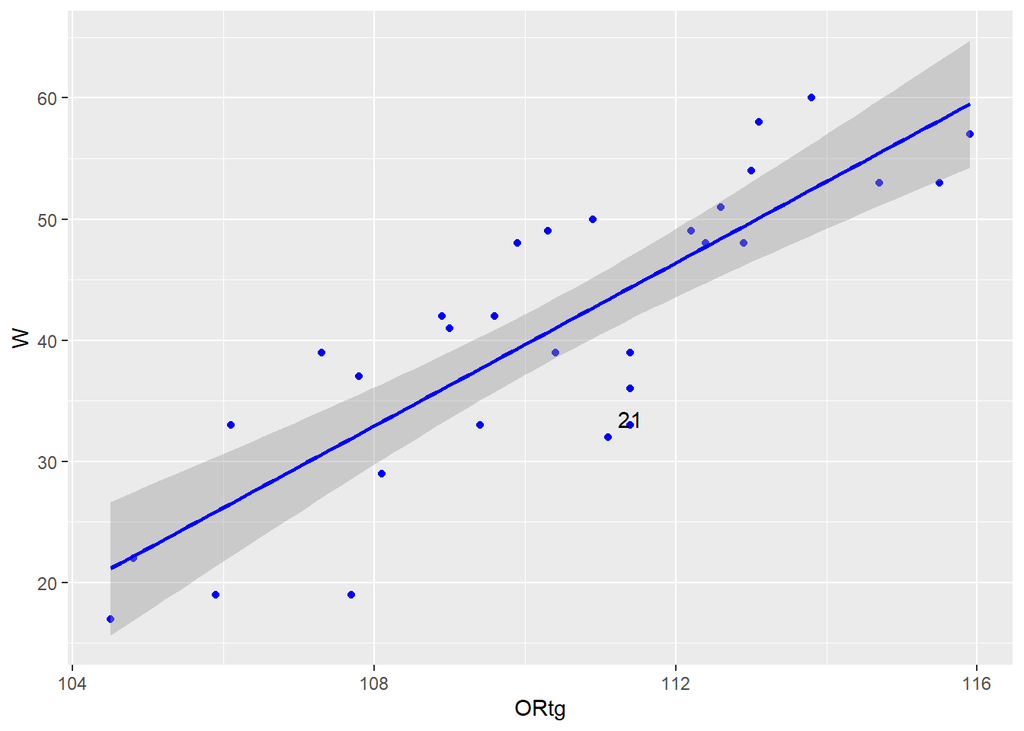

```r
ggplot(team_statistics_sum, aes(x = ORtg, y = W))+
  geom_point(alpha = 1, colour = "blue")+
  geom_smooth(method = "lm", colour = "blue")+
  theme_gray()+
  geom_text(aes(label = cook_labels), nudge_y = 0.5)
```

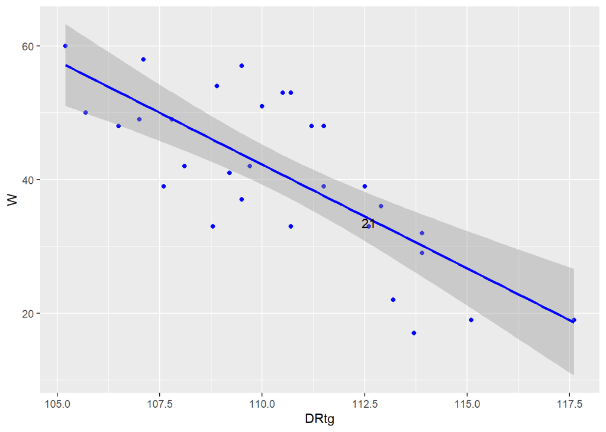

```r
ggplot(team_statistics_sum, aes(x = DRtg, y = W))+
  geom_point(alpha = 1, colour = "blue")+
  geom_smooth(method = "lm", colour = "blue")+
  theme_gray()+
  geom_text(aes(label = cook_labels), nudge_y = 0.5)
```

**21 show in both graph**

```r
# create new df without the high influence points
outliers <- c(21)
filtered_df <- team_statistics_sum %>%
  filter(!"RK.x" %in% outliers)


fit <- lm(W ~ ORtg + DRtg , data = filtered_df)
tidy(fit,conf.int = TRUE)
```

```
## # A tibble: 3 x 7
##   term        estimate std.error statistic  p.value conf.low conf.high
##   <chr>          <dbl>     <dbl>     <dbl>    <dbl>    <dbl>     <dbl>
## 1 (Intercept)    -7.77    28.1      -0.276 7.84e- 1   -65.4      49.9
## 2 ORtg            2.64     0.154    17.1   4.86e-16     2.33      2.96
## 3 DRtg           -2.20     0.157   -14.0   7.15e-14    -2.52     -1.88
```

```r
summary(fit)
```

```
##
## Call:
## lm(formula = W ~ ORtg + DRtg, data = filtered_df)
##
## Residuals:
##     Min      1Q  Median      3Q     Max
## -5.8096 -1.0779  0.1196  1.4373  4.1294
##
## Coefficients:
##             Estimate Std. Error t value Pr(>|t|)
## (Intercept)  -7.7664    28.1126  -0.276    0.784
## ORtg          2.6414     0.1541  17.145 4.86e-16 ***
## DRtg         -2.1996     0.1575 -13.967 7.15e-14 ***
## ---
## Signif. codes:  0 '***' 0.001 '**' 0.01 '*' 0.05 '.' 0.1 ' ' 1
##
## Residual standard error: 2.351 on 27 degrees of freedom
## Multiple R-squared:  0.9644, Adjusted R-squared:  0.9618
## F-statistic: 366.1 on 2 and 27 DF,  p-value: < 2.2e-16
```

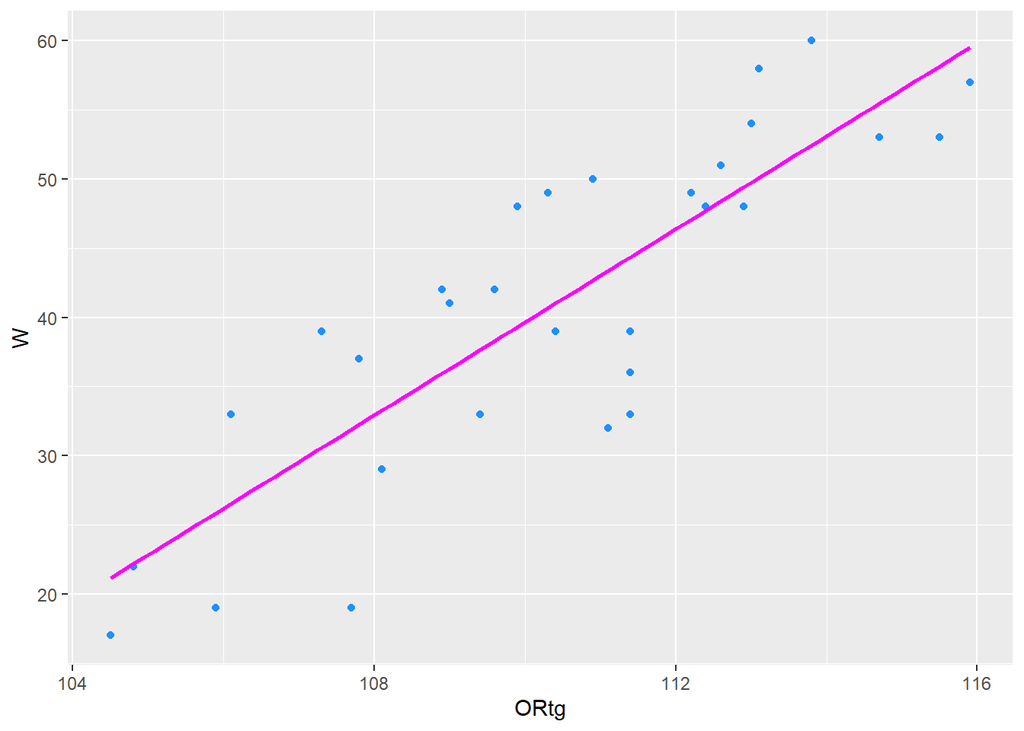

```r
ggplot(data = filtered_df, aes(x = ORtg, y = W)) +
  geom_point(colour = "dodgerblue") +
  geom_smooth(method = "lm", colour = "magenta", se = FALSE)
```

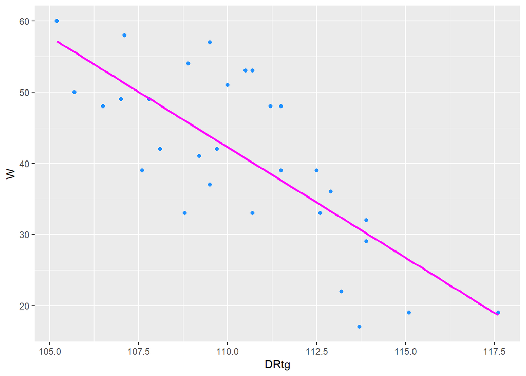

```r
  ggplot(data = filtered_df, aes(x = DRtg, y = W)) +
  geom_point(colour = "dodgerblue") +
  geom_smooth(method = "lm", colour = "magenta", se = FALSE)
```